# Motif Analysis

Amy Huang

2023-03-10

# Purpose

To answer the question, “What are the transcriptional regulators of the exhaustion associated enhancer and how are they expressed in the different subpopulations?

# Set up

To start, read in the Seurat object.

```r
so <-
  readRDS(here(
    "scRNAseq",
    "data",
    "processed_data_objects",
    "00_seurat_workflow.so.rds"
  ))
```

# Genes identified in the motif analysis

First, get the otput from FIMO analysis for the enhancer region.

```r
exh_enh_test_fimo <-
  read_tsv(here("scRNAseq", "data", "exh_enh_test_fimo.tsv")) %>%
  filter(!is.na(sequence_name)) %>%
  mutate(motif_gene = motif_alt_id %>% str_extract("\\.[:alnum:]*$")) %>%
  mutate(motif_gene = str_sub(motif_gene, start = 2)) %>%
  dplyr::relocate(motif_gene, .before = motif_id)
```

There are 620 motif significantly associated with the deleted enhancer. However, not all of those are mouse genes. Many motifs actually associate with human or yeast genes, e.g.:

```r
exh_enh_test_fimo$motif_gene %>% head()
```

```
## [1] "MYB96" "MYB96" "Klf15" "MYB30" "MYB31" "RREB1"
```

To identify all the mouse associated genes, we’re going to pull out any genes which appear in the gene list that the single cell data was aligned to. You can find this information in the `features.tsv` file from the counts matrices output from the cellranger pipeline.

Note, we are not using simply the genes present in the Seurat object, since that isn’t a full list of genes.

```r
dirs <- list.files(here("scRNAseq", "data", "counts_matrices"))
unique_genes <- dirs %>%
  map_dfr(~ read_tsv(
    here("scRNAseq", "data", "counts_matrices", ..1, "features.tsv.gz"),
    col_names = FALSE
  ), .id = "sample") %>%
  .$X2 %>%
  unique()
```

There are 27933 unique genes in the mouse transcriptome used (mm10 v.1.2.0). If we look for genes found in the motif analysis, there are 39 genes, which are:

```r
intersect(unique_genes, exh_enh_test_fimo$motif_gene) %>% sort()
```

```
##  [1] "Atoh1"   "Atoh7"   "Bhlha15" "Ebf2"    "Erg"     "Foxq1"   "Gata3"
##  [8] "Gli1"    "Gli2"    "Hic1"    "Hoxd13"  "Ikzf3"   "Irf1"    "Klf15"
## [15] "Msgn1"   "Neurod2" "Nr2f6"   "Olig2"   "Plagl1"  "Prdm5"   "Ptf1a"
## [22] "Rarb"    "Rarg"    "Rel"     "Runx1"   "Rxra"    "Smad4"   "Sox11"
## [29] "Sox6"    "Stat2"   "Stat4"   "Stat5a"  "Stat5b"  "Stat6"   "Tcf12"
## [36] "Tcf21"   "Twist2"  "Zic2"    "Zic3"
```

## GO term enrichment of motif genes

```r
library(clusterProfiler)
library(org.Mm.eg.db)
ego <- enrichGO(
  gene          = intersect(unique_genes, exh_enh_test_fimo$motif_gene),
  universe      = unique_genes,
  OrgDb         = org.Mm.eg.db,
  keyType       = "SYMBOL",
  ont           = "ALL",
  pAdjustMethod = "BH",
  pvalueCutoff  = 0.01,
  qvalueCutoff  = 0.05
)
saveRDS(ego, here("scRNAseq", "data", "exh_enh_test_fimo_enrichGO.rds"))

write_csv(as_tibble(ego@result), here("scRNAseq", "data", "exh_enh_test_fimo_enrichGO.csv"))
```

The top pathways have to do with development, or cell fate commitment. Of the significant pathways, there are 8 pathways that have the word “lymphocyte” or “T cell”.

```r
ego_out <- read_csv(here("scRNAseq", "data", "exh_enh_test_fimo_enrichGO.csv"))
ego_out %>%
  filter(ONTOLOGY == "BP") %>%
  filter(qvalue < 0.0001) %>%
  arrange(pvalue) %>%
  head(5) %>%
  dplyr::select(Description, geneID)
```

```
## # A tibble: 5 × 2
##   Description                   geneID
##   <chr>                         <chr>
## 1 gland development             Gli2/Gata3/Ptf1a/Rxra/Hoxd13/Zic3/Tcf21/Gli1/St…
## 2 cell fate commitment          Gli2/Gata3/Ptf1a/Atoh1/Sox6/Stat6/Ebf2/Olig2/Ru…
## 3 embryonic organ morphogenesis Twist2/Gli2/Gata3/Zic3/Atoh1/Tcf21/Gli1/Rarb/So…
## 4 urogenital system development Gli2/Gata3/Rxra/Hoxd13/Klf15/Tcf21/Rarb/Stat5a/…
## 5 embryonic organ development   Twist2/Gli2/Gata3/Zic3/Atoh1/Tcf21/Gli1/Rarb/So…
```

```r
ego_out %>%
  filter(ONTOLOGY == "BP") %>%
  filter(qvalue < 0.0001) %>%
  filter(str_detect(Description, "lymphocyte|T cell")) %>%
  arrange(pvalue) %>%
  dplyr::select(Description, geneID)
```

```
## # A tibble: 8 × 2
##   Description                                       geneID
##   <chr>                                             <chr>
## 1 regulation of lymphocyte activation               Gata3/Stat6/Irf1/Ikzf3/Stat…
## 2 positive regulation of T cell differentiation     Gata3/Irf1/Stat5b/Stat5a/Ru…
## 3 regulation of lymphocyte differentiation          Gata3/Irf1/Ikzf3/Stat5b/Sta…
## 4 positive regulation of lymphocyte differentiation Gata3/Irf1/Stat5b/Stat5a/Ru…
## 5 lymphocyte differentiation                        Gata3/Stat6/Irf1/Ikzf3/Stat…
## 6 positive regulation of lymphocyte activation      Gata3/Stat6/Irf1/Stat5b/Sta…
## 7 regulation of T cell differentiation              Gata3/Irf1/Stat5b/Stat5a/Ru…
## 8 T cell differentiation                            Gata3/Stat6/Irf1/Stat5b/Sta…
```

# Gene Expression Analysis

```r
lymphocyte_activation_genes <- ego_out %>%
  filter(Description == "regulation of lymphocyte activation") %>%
  .$geneID %>%
  str_split("/") %>%
  .[[1]]
lymphocyte_activation_genes
```

```
## [1] "Gata3"  "Stat6"  "Irf1"   "Ikzf3"  "Stat5b" "Stat5a" "Sox11"  "Runx1"
```

There are 22 genes that the motif analysis found in the Seurat object:

```r
motif_genes <- intersect(rownames(so@assays$RNA), exh_enh_test_fimo$motif_gene)
motif_genes
```

```
##  [1] "Stat4"   "Twist2"  "Gata3"   "Rxra"    "Bhlha15" "Prdm5"   "Plagl1"
##  [8] "Stat6"   "Stat2"   "Nr2f6"   "Tcf12"   "Rel"     "Irf1"    "Hic1"
## [15] "Ikzf3"   "Stat5b"  "Stat5a"  "Rarg"    "Runx1"   "Smad4"   "Foxq1"
## [22] "Erg"
```

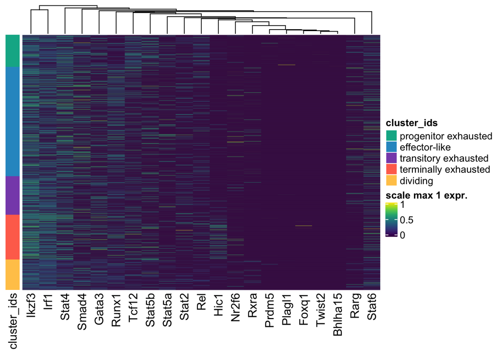

```r
h_tbl <-
  get_metadata_from_so(so, genes = motif_genes, metadata = c("genotype", "cluster_ids")) %>%
  filter(genotype == "W") %>%
  dplyr::select(-UMAP_1, -UMAP_2, -genotype, -Erg) %>%
  arrange(cluster_ids)
h_df <- h_tbl %>%
  dplyr::select(cell, cluster_ids) %>%
  column_to_rownames("cell")
row_ann <- rowAnnotation(
  df = h_df,
  col = list(cluster_ids = palette_cluster_ids)
)
h_mtx <- h_tbl %>%
  dplyr::select(-cluster_ids) %>%
  pivot_longer(cols = 2:ncol(.)) %>%
  group_by(name) %>%
  mutate(scale_max_expr = value / max(value)) %>%
  pivot_wider(id_cols = cell, values_from = scale_max_expr) %>%
  column_to_rownames("cell") %>%
  as.matrix()
h <- Heatmap(
  h_mtx,
  name = "scale max 1 expr.",
  col = viridis(20),
  show_row_names = FALSE,
  cluster_rows = FALSE,
  left_annotation = row_ann
)
h
```

```r
h_gene_ordering <- c("Ikzf3", "Irf1", "Stat4",
  "Smad4", "Gata3", "Runx1",
  "Tcf12", "Stat5b", "Stat5a",
  "Stat2", "Rel", "Hic1",
  "Nr2f6", "Rxra", "Prdm5",
  "Plagl1", "Foxq1", "Twist2",
  "Bhlha15", "Rarg", "Stat6")
```

```r
mean_expr_df <- get_metadata_from_so(so, genes = motif_genes) %>%
  filter(genotype == "W") %>%
  pivot_longer(cols = motif_genes,
               names_to = "gene") %>%
  group_by(gene) %>%
  summarise(mean_expr = mean(value))
mean_cluster_expr_df <- get_metadata_from_so(so, genes = motif_genes) %>%
  filter(genotype == "W") %>%
  pivot_longer(cols = motif_genes,
               names_to = "gene") %>%
  group_by(cluster_ids, gene) %>%
  summarise(mean_expr = mean(value)) %>%
  group_by(gene) %>%
  mutate(zscore_mean_expr = as.vector(scale(mean_expr)),
         scale_max_mean_expr = mean_expr / max(mean_expr))
```

```r
h_mean <- mean_cluster_expr_df %>%
  filter(gene != "Erg") %>%
  mutate(cluster_ids = factor(cluster_ids,
                              levels = rev(names(palette_cluster_ids)))) %>%
  mutate(gene = factor(gene, levels = h_gene_ordering)) %>%
  ggplot() +
  aes(gene, cluster_ids, fill = scale_max_mean_expr) +
  geom_tile() +
  # geom_text(aes(label = format(mean_expr, digits = 2)), angle = 90) +
  scale_fill_viridis_c() +
  remove_spines() +
  labs(fill = "scale max 1 expr") +
  theme(axis.text.x = element_text(angle = 90, hjust = 1))
```

```r
out_df <-
  get_metadata_from_so(so,
                       genes = motif_genes,
                       metadata = c("genotype", "cluster_ids", "orig.ident")) %>%
  filter(genotype == "W") %>%
  filter(cluster_ids %in% c("progenitor exhausted", "terminally exhausted")) %>%
  dplyr::select(-genotype) %>%
  pivot_longer(cols = motif_genes) %>%
  filter(name != "Erg") %>%
  named_group_split(name) %>%
  map_dfr(~ ..1 %>%
            summarise(w_out = wilcox.test(value ~ cluster_ids, data = .) %>%
                        broom::tidy()),
          .id = "name") %>%
  unnest(w_out)

p_sig_term.v.prog <- out_df %>%
  arrange(p.value) %>%
  mutate(FDR = p.adjust(p.value, method = "BH")) %>%
  mutate(gene = factor(name, levels = h_gene_ordering)) %>%
  ggplot() +
  aes(gene, -log10(FDR)) +
  geom_col() +
  geom_point(aes(y = -log10(FDR) + 0.5),
             data = ~..1 %>% filter(FDR < 0.05),
             color = "red",
             shape = 8) +
  geom_hline(yintercept = -log10(0.05), color = "red", linetype = "dotted") +
  remove_spines() +
  scale_y_continuous(expand = c(0, 0), limits = ~c(0, ..1[2]*1.05)) +
  theme(axis.title.x = element_blank(),
        axis.text.x = element_text(angle = 90, hjust = 1))
```

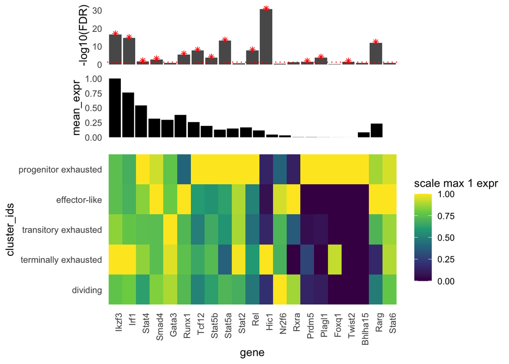

```r
p_expr <- mean_expr_df %>%
  mutate(gene = factor(gene, levels = h_gene_ordering)) %>%
  ggplot() +
  aes(gene, mean_expr) +
  geom_col(fill = "black") +
  remove_spines() +
  scale_y_continuous(expand = c(0, 0)) +
  theme(axis.text.x = element_blank(),
        axis.title.x = element_blank())
plot_grid(
  p_sig_term.v.prog + theme(axis.text.x = element_blank()),
  p_expr,
  h_mean,
  ncol = 1,
  axis = "lr",
  align = "v",
  rel_heights = c(1, 1, 3)
)
```

# TFs from Sen et al. Science 2015 CRISPR tiling screen

The relevant TFs are SOX3, TBX21, RAR. Associated genes should be Sox3, Tbx21, Rara, Rarg

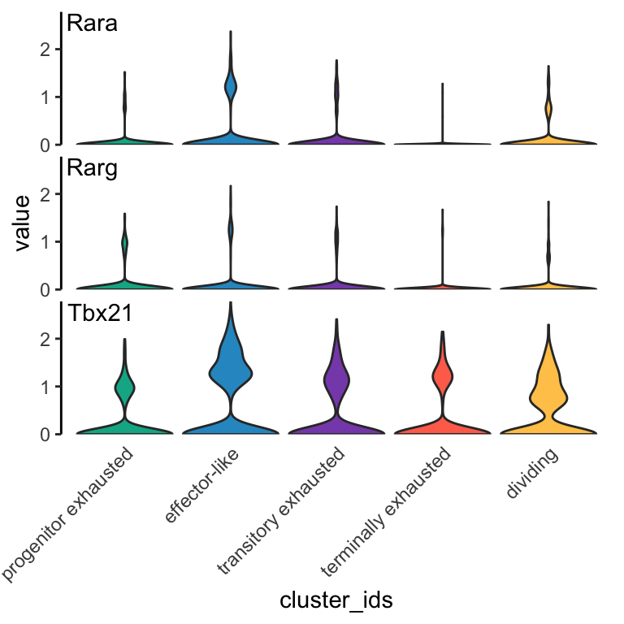

```r
get_metadata_from_so(so, genes = c("Tbx21", "Rara", "Rarg")) %>%
  filter(genotype == "W") %>%
  pivot_longer(cols = c("Tbx21", "Rara", "Rarg"),
               names_to = "gene") %>%
  plot_violin(group = cluster_ids, var = value) +
  geom_text(aes(label = gene, fill = NA),
            x = -Inf,
            y = Inf,
            hjust = -0.1,
            vjust = 1.1,
            data = ~..1 %>%
              dplyr::select(gene) %>%
              unique()) +
  facet_grid(gene~.) +
  scale_fill_manual(values = palette_cluster_ids) +
  theme(axis.text.x = element_text(angle = 45, hjust = 1, vjust = 1),
        strip.text.y = element_blank(),
        strip.background = element_blank())
```